# ISSP Chile 1999, 2009 & 2019 - Salary Gap & meritocracy

Julio César Iturra Sanhueza - jciturra@uc.cl

# Brechas salarios percibida y justa

- Hacer un par de boxplot para cada variable de Obrero Gerente (hacer pull luego de esto).
- CASEN (2009,2011,2013,2015,2017): Cálculo de los salarios por ocupación (media y mediana).
  - Emplear diseño muestral complejo

# Gráficos

## Boxplot salario percibido

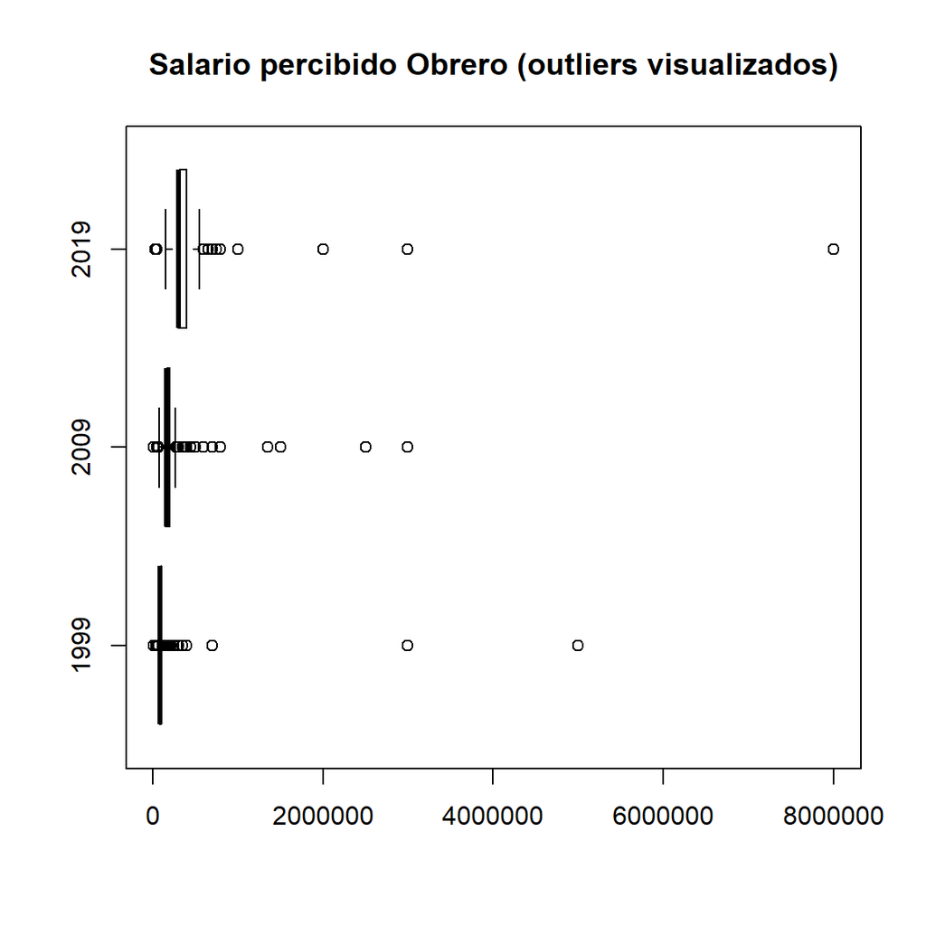

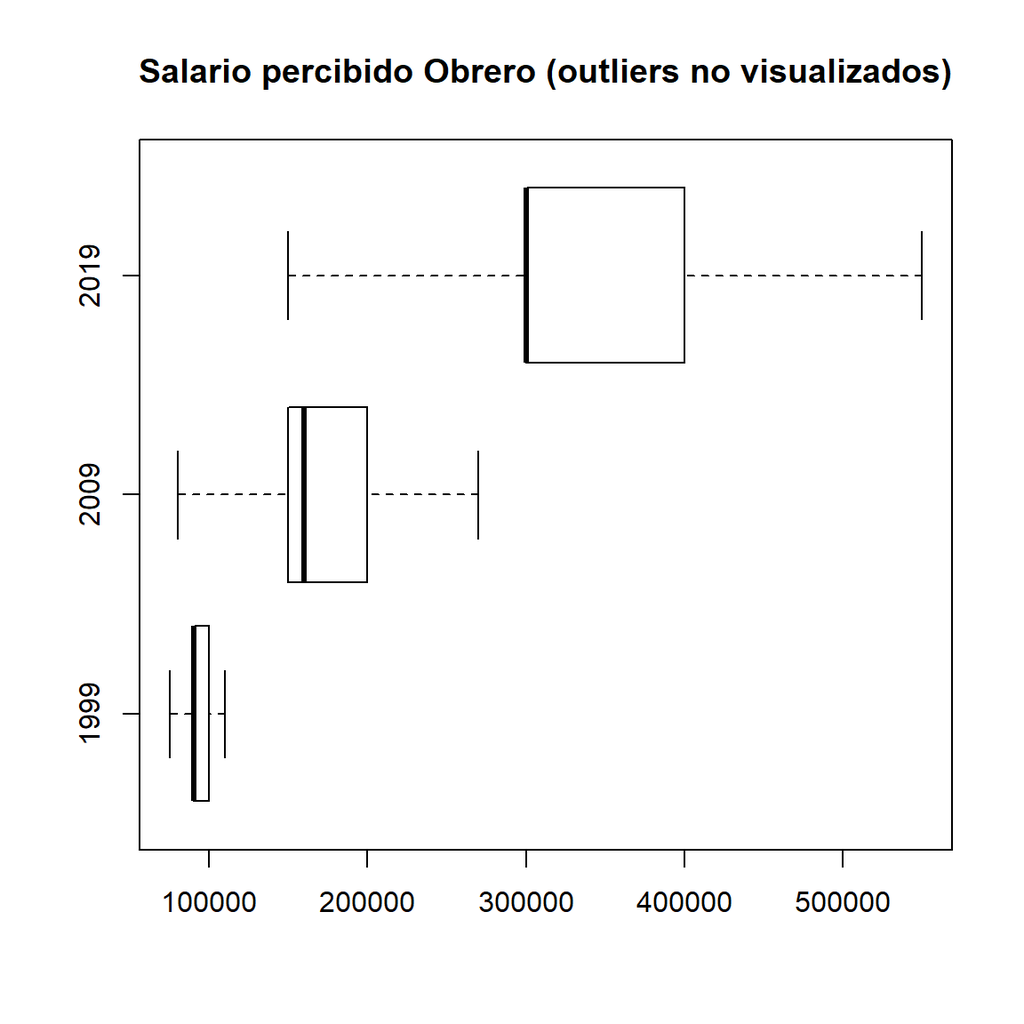

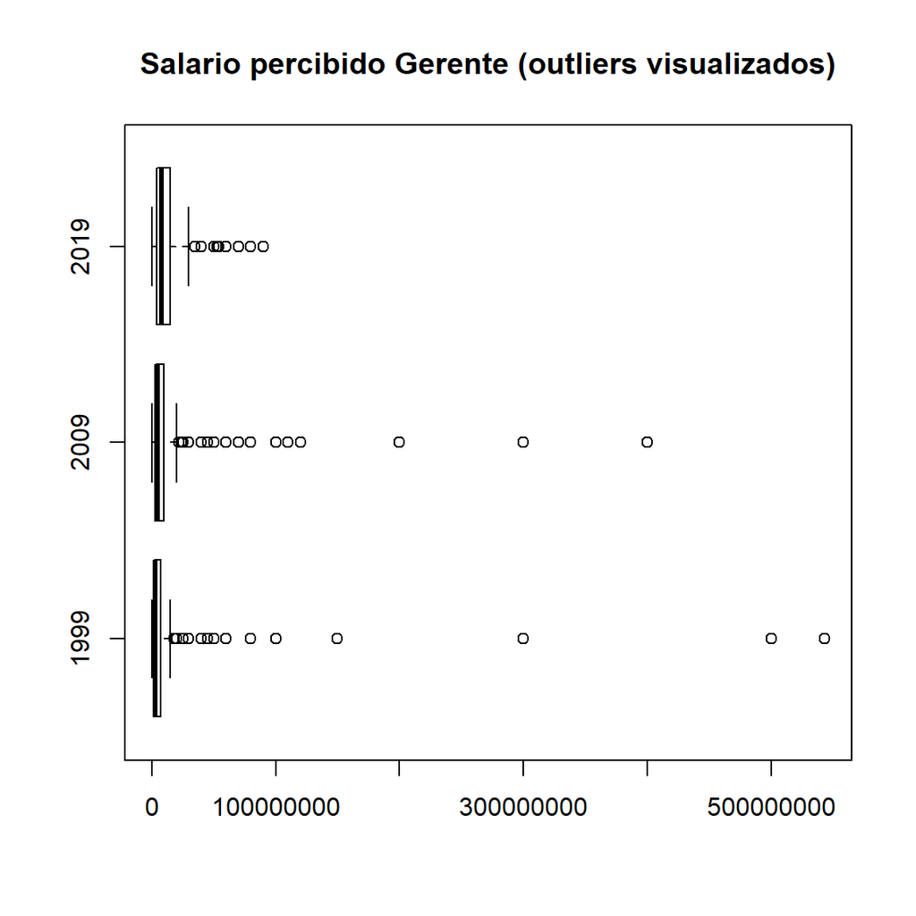

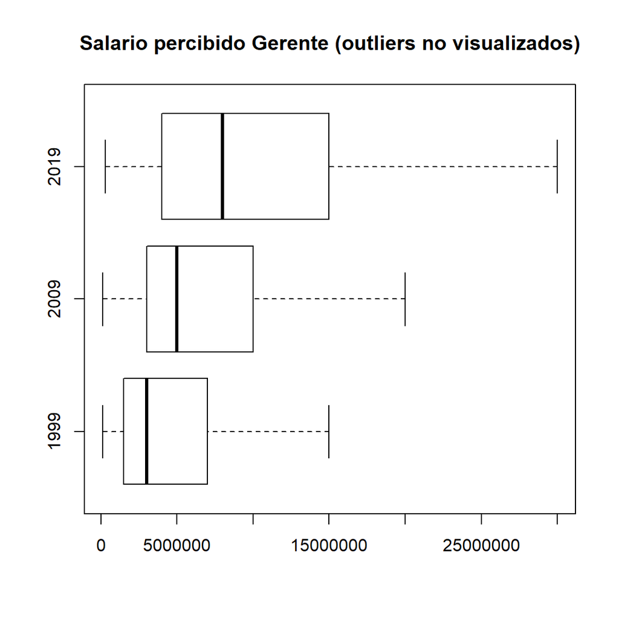

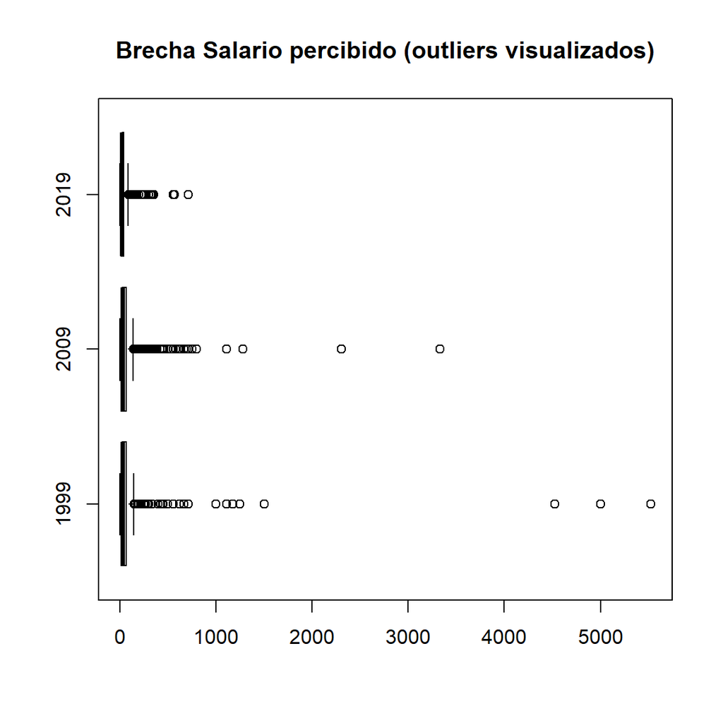

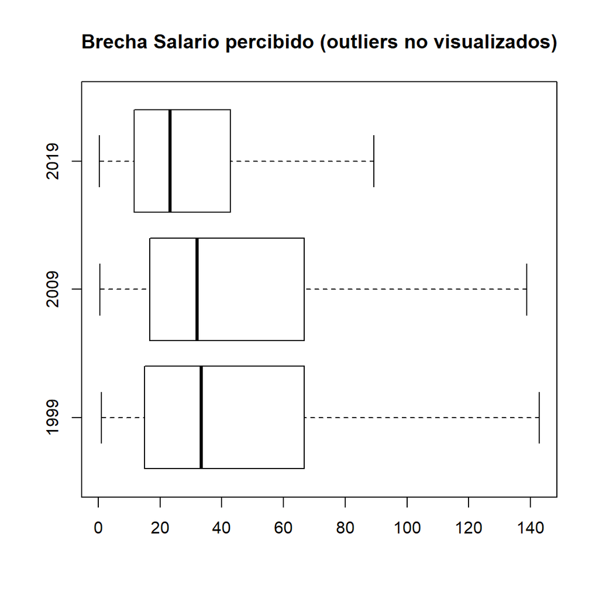

## Boxplot salario justo

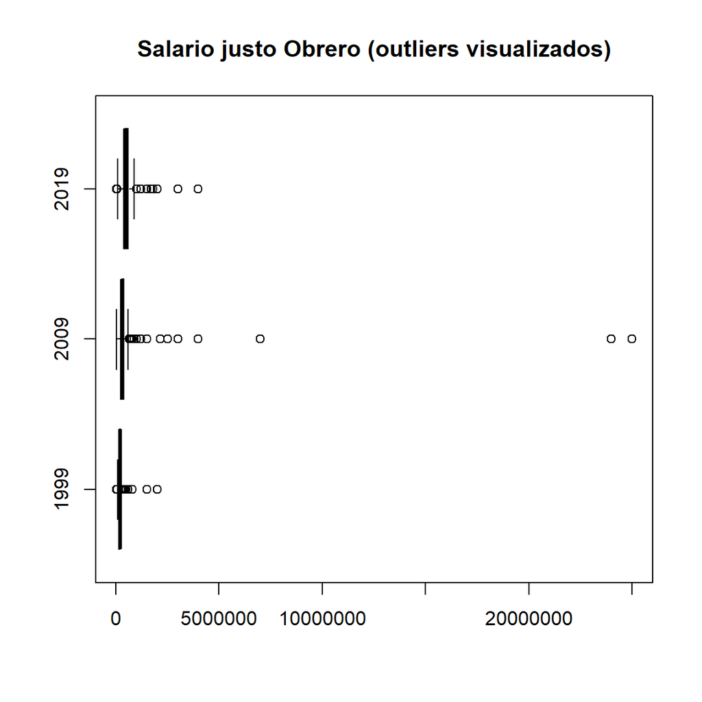

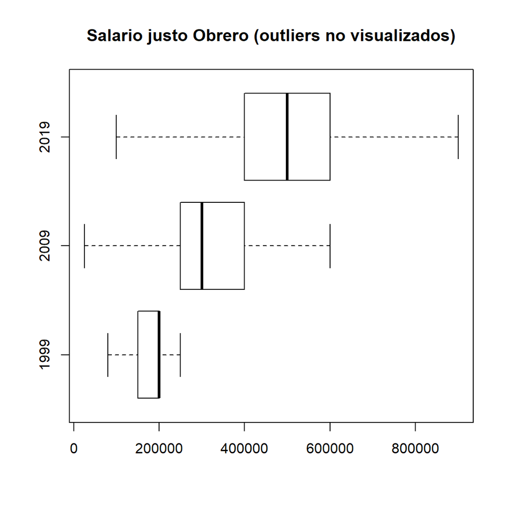

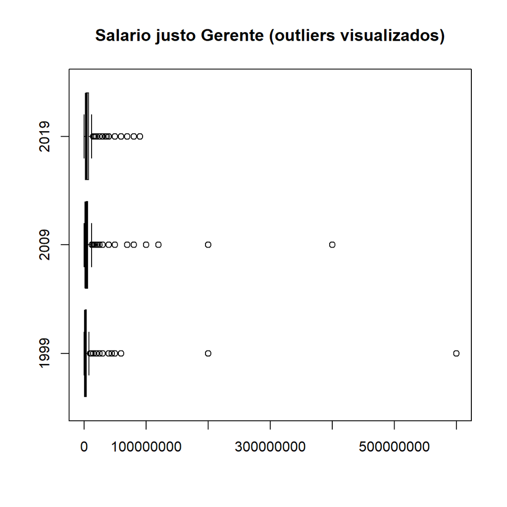

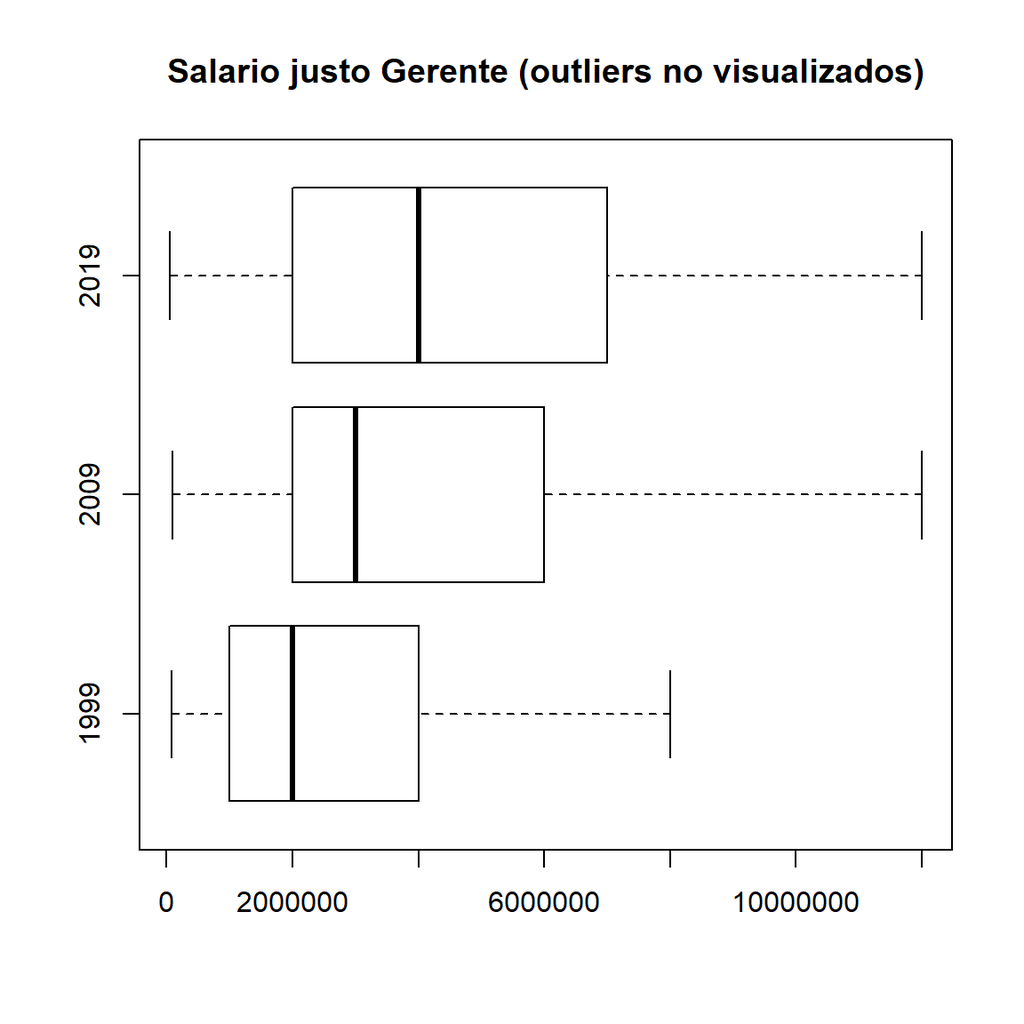

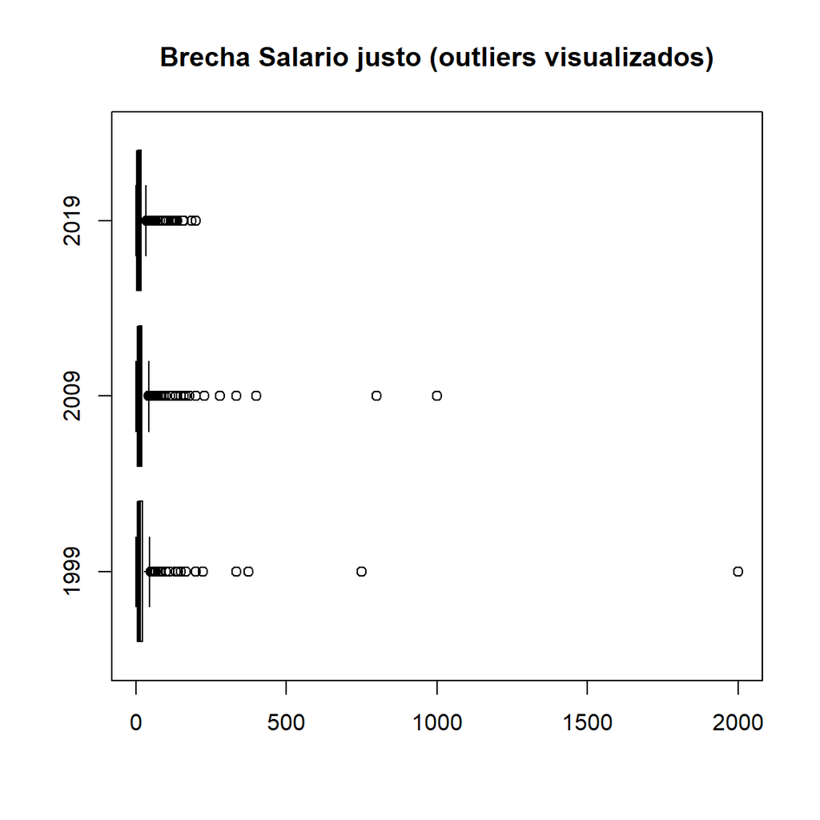

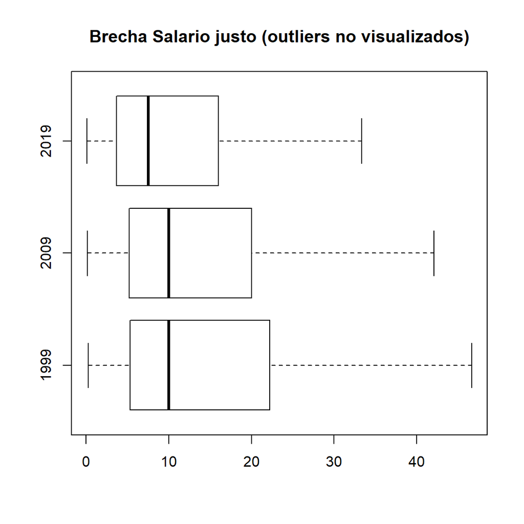

## Brecha total

Brecha total de salario percibido por año

|  | n | mean | sd | median | trimmed | min | max |
| --- | --- | --- | --- | --- | --- | --- | --- |
| 1999 | 914 | 89.62 | 323.95 | 33.33 | 42.68 | 0.01 | 5524.86 |
| 2009 | 1337 | 603.63 | 6496.84 | 32.14 | 42.39 | 0.04 | 133333.33 |
| 2019 | 1037 | 279.97 | 3348.29 | 23.33 | 28.20 | 0.31 | 60000.00 |

Tabla: Brecha total de salario justo por año

|  | n | mean | sd | median | trimmed | min | max |
| --- | --- | --- | --- | --- | --- | --- | --- |
| 1999 | 854 | 24.62 | 103.04 | 10.0 | 13.85 | 0.02 | 2000 |
| 2009 | 1318 | 192.32 | 2158.49 | 10.0 | 14.05 | 0.00 | 40000 |
| 2019 | 977 | 66.42 | 764.77 | 7.5 | 9.42 | 0.08 | 14000 |

Tabla: Brecha total de salario justo por año

|  | n | mean | sd | median | trimmed | min | max |
| --- | --- | --- | --- | --- | --- | --- | --- |
| 1999 | 836 | 24.83 | 104.08 | 10.0 | 13.96 | 0.25 | 2000 |
| 2009 | 1283 | 21.11 | 46.93 | 10.0 | 13.66 | 0.16 | 1000 |
| 2019 | 956 | 13.92 | 22.57 | 7.5 | 9.40 | 0.08 | 200 |

Note:  
Calculo realizado sin casos extremos superiores e inferiores Media recortada sin el 5% de cada extremo

Tabla: Brecha total de salario percibido por año

|  | n | mean | sd | median | trimmed | min | max |
| --- | --- | --- | --- | --- | --- | --- | --- |
| 1999 | 881 | 87.00 | 319.11 | 33.33 | 43.10 | 1.00 | 5524.86 |
| 2009 | 1283 | 68.30 | 154.09 | 32.05 | 41.69 | 0.56 | 3333.33 |
| 2019 | 1006 | 39.09 | 55.74 | 23.33 | 27.84 | 0.31 | 714.29 |

Note:  
Calculo realizado sin casos extremos superiores e inferiores Media recortada sin el 5% de cada extremo

## Brecha estimada (log)

Brecha total de ln(salario percibido) por año

|  | n | mean | sd | median | trimmed | min | max |
| --- | --- | --- | --- | --- | --- | --- | --- |
| 1999 | 914 | 3.51 | 1.27 | 3.51 | 3.49 | -4.38 | 8.62 |
| 2009 | 1337 | 3.58 | 1.31 | 3.47 | 3.51 | -3.22 | 11.80 |
| 2019 | 1037 | 3.17 | 1.18 | 3.15 | 3.12 | -1.16 | 11.00 |

Tabla: Brecha total de ln(salario justo) por año

|  | n | mean | sd | median | trimmed | min | max |
| --- | --- | --- | --- | --- | --- | --- | --- |
| 1999 | 854 | 2.41 | 1.13 | 2.30 | 2.41 | -3.98 | 7.60 |
| 2009 | 1318 | 2.45 | 1.32 | 2.30 | 2.41 | -6.40 | 10.60 |
| 2019 | 977 | 2.04 | 1.21 | 2.01 | 2.00 | -2.48 | 9.55 |

Tabla: Brecha total de ln(salario justo) por año

|  | n | mean | sd | median | trimmed | min | max |
| --- | --- | --- | --- | --- | --- | --- | --- |
| 1999 | 836 | 2.43 | 1.06 | 2.30 | 2.42 | -1.39 | 7.60 |
| 2009 | 1283 | 2.40 | 1.08 | 2.30 | 2.39 | -1.83 | 6.91 |
| 2019 | 956 | 2.01 | 1.09 | 2.01 | 2.01 | -2.48 | 5.30 |

Note:  
Calculo realizado sin casos extremos superiores e inferiores Media recortada sin el 5% de cada extremo

Tabla: Brecha total de ln(salario percibido) por año

|  | n | mean | sd | median | trimmed | min | max |
| --- | --- | --- | --- | --- | --- | --- | --- |
| 1999 | 881 | 3.54 | 1.17 | 3.51 | 3.50 | 0.00 | 8.62 |
| 2009 | 1283 | 3.53 | 1.09 | 3.47 | 3.50 | -0.59 | 8.11 |
| 2019 | 1006 | 3.12 | 1.03 | 3.15 | 3.12 | -1.16 | 6.57 |

Note:  
Calculo realizado sin casos extremos superiores e inferiores Media recortada sin el 5% de cada extremo

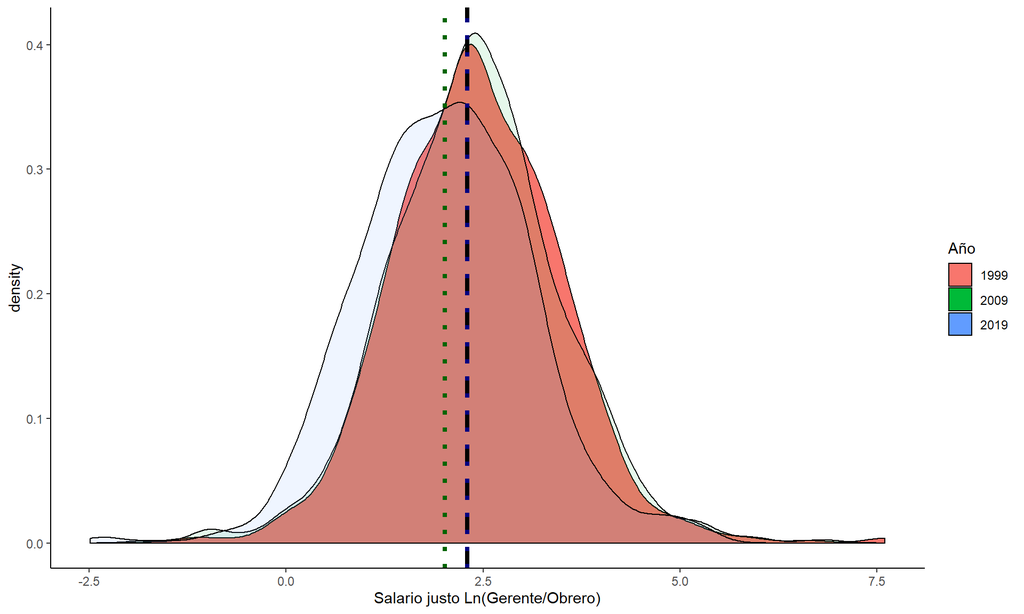

# Meritocracia

## 1999

### Percepción

**(1) Esencial - No tiene importancia (5)** (8 no sabe, 9 no responde)

- v4: Importancia para surgir: provenir familia rica (wfami)
- V5: Importancia para surgir: Conocer personas adecuadas (knope)

**(1) Muy de acuerdo - Muy en desacuerdo (5)** (8 no sabe, 9 no responde)

- v6: Recompensas: En Chile las personas son remuneradas por sus esfuerzos (refor)
- v7: Recompensas: En Chile las personas son remuneradas por su inteligencia y capacidades (rinte)
- v8: Hoy en día, para llegar hasta el nivel más alto en Chile, hay que ser corrupto. (corru)

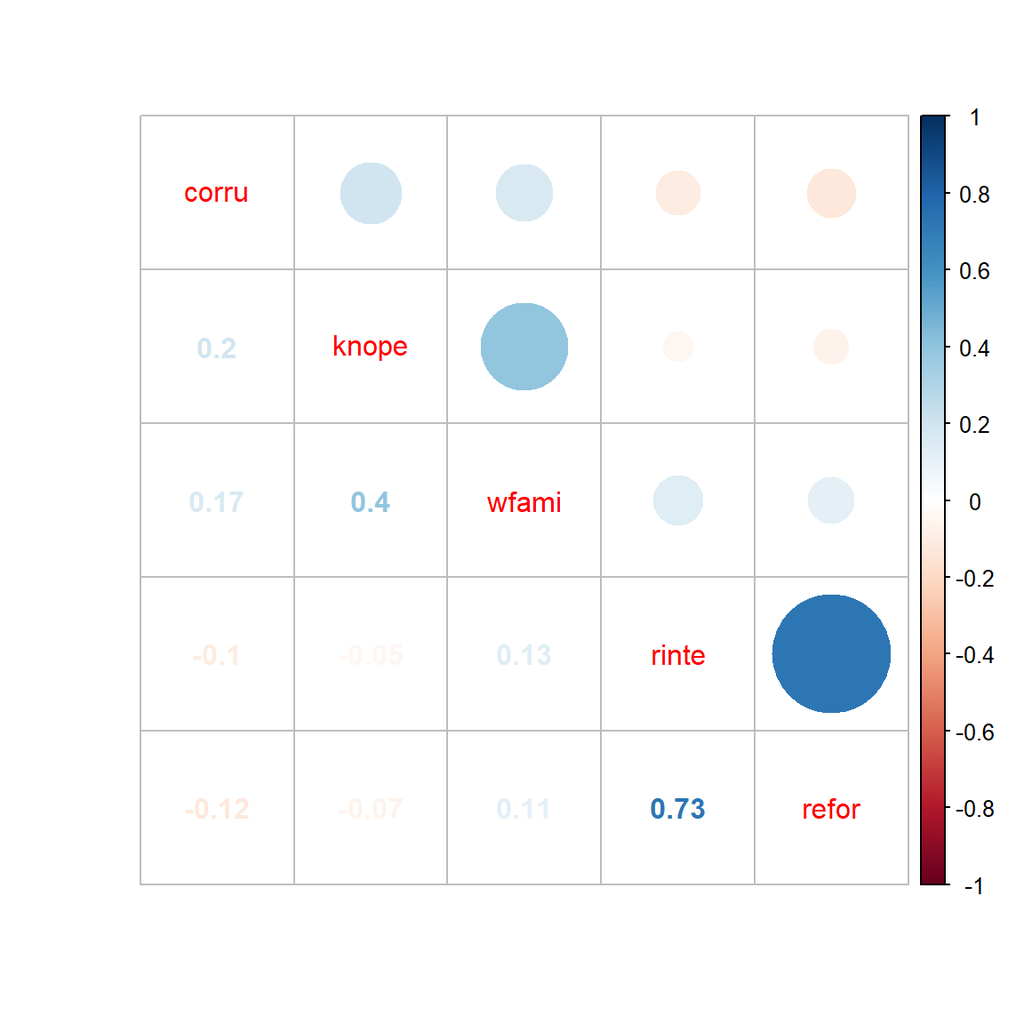

**Correlación Policórica para Batería de *Percepción* de Meritocracia para Chile ISSP 1999**

Analisis Factorial 1999 Percepcion

|  | Factor 1 | Factor 2 |
| --- | --- | --- |
| Importance: coming from a wealthy famil | 0.09 | 0.62 |
| Importance: Knowing the right people | -0.09 | 0.59 |
| People get rewarded for their effort | 0.78 | -0.02 |
| People get rewarded for their skills | 0.84 | 0.02 |
| Cronbach’s α | 0.79 | 0.52 |

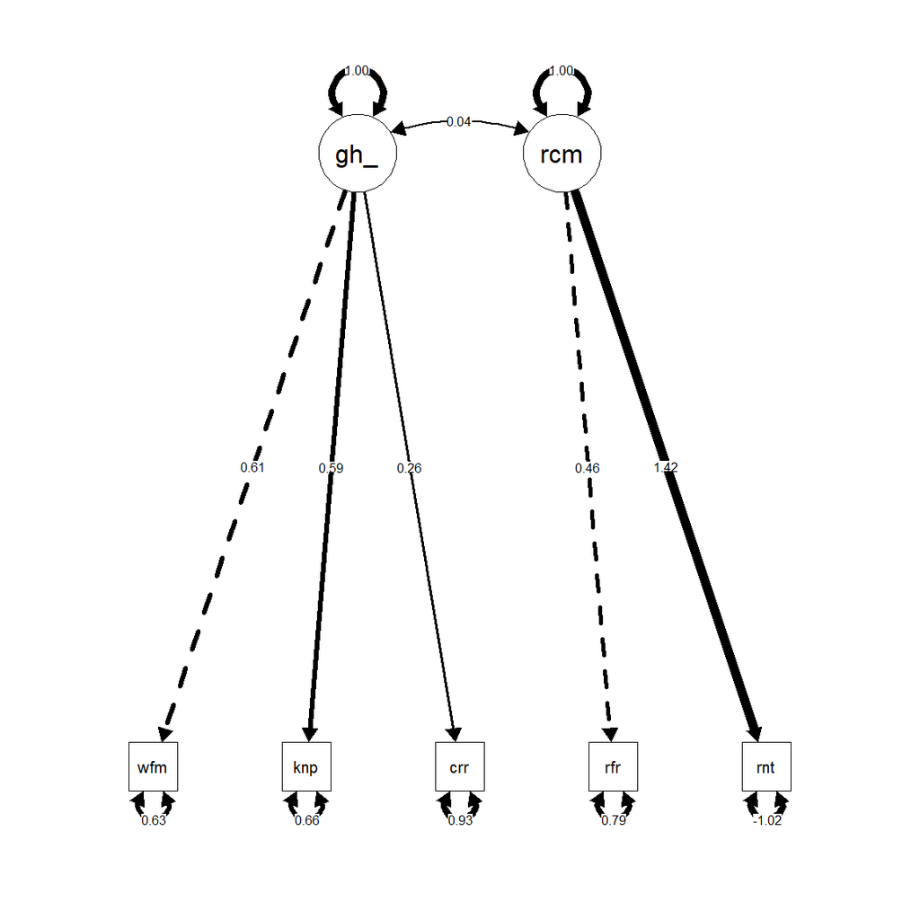

### Preferencia

**(1) Esencial - No tiene importancia (5)** (8 no sabe, 9 no responde) OO - v49:Importancia para pagar: nivel de responsabilidadad asociado al trabajo (respo)

- v50:Importancia para pagar: numero de años dedicados a educación y capacitación (neduc)
- v51:Importancia para pagar: si el trabajo requiere que se supervise a otras personas (suprv)
- v52:Importancia para pagar: Lo que se necesita para mantener a una familia (mafam)
- v53:Importancia para pagar: Que una persona tenga hijos que mantener (hchil)
- v54:Importancia para pagar: Lo bien que él/ella realiza su trabajo (gdwrk)
- v55:Importancia para pagar: Cuánto se esfuerza él ella en realizar su trabajo (effor)

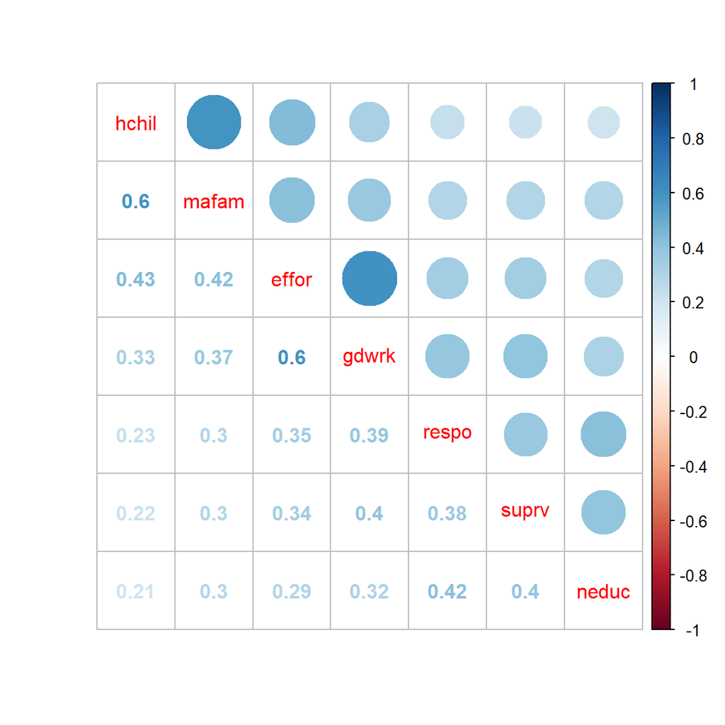

**Correlación Policórica para Batería de *Preferencias* en Meritocracia para Chile ISSP 1999**

Analisis Factorial 1999 Preferencia

|  | Factor 1 | Factor 2 | Factor 3 |
| --- | --- | --- | --- |
| Importance to pay: responsibility | -0.03 | 0.08 | 0.54 |
| Importance to pay: education & training | 0.02 | -0.13 | 0.67 |
| Importance to pay: supervising others | -0.00 | 0.12 | 0.45 |
| Importance to pay: supporting a family | 0.59 | 0.04 | 0.11 |
| Importance to pay: having children | 0.90 | -0.04 | -0.09 |
| Importance to pay: how well they do it | -0.10 | 0.84 | 0.00 |
| Importance to pay: how hard they work | 0.14 | 0.61 | -0.02 |
| Cronbach’s α | 0.70 | 0.68 | 0.57 |

```
## lavaan 0.6-3 ended normally after 24 iterations
##
##   Optimization method                           NLMINB
##   Number of free parameters                         38
##
##                                                   Used       Total
##   Number of observations                          1412        1503
##
##   Estimator                                       DWLS      Robust
##   Model Fit Test Statistic                      41.286      79.425
##   Degrees of freedom                                11          11
##   P-value (Chi-square)                           0.000       0.000
##   Scaling correction factor                                  0.525
##   Shift parameter                                            0.729
##     for simple second-order correction (Mplus variant)
##
## Model test baseline model:
##
##   Minimum Function Test Statistic             7506.930    4915.746
##   Degrees of freedom                                21          21
##   P-value                                        0.000       0.000
##
## User model versus baseline model:
##
##   Comparative Fit Index (CFI)                    0.996       0.986
##   Tucker-Lewis Index (TLI)                       0.992       0.973
##
##   Robust Comparative Fit Index (CFI)                            NA
##   Robust Tucker-Lewis Index (TLI)                               NA
##
## Root Mean Square Error of Approximation:
##
##   RMSEA                                          0.044       0.066
##   90 Percent Confidence Interval          0.030  0.059       0.053  0.080
##   P-value RMSEA <= 0.05                          0.725       0.022
##
##   Robust RMSEA                                                  NA
##   90 Percent Confidence Interval                                NA     NA
##
## Standardized Root Mean Square Residual:
```

[output cut: 81 more lines]

```
##    .gdwrk             0.407                               0.407    0.407
##    .effor             0.371                               0.371    0.371
##     resp              0.427    0.029   14.684    0.000    1.000    1.000
##     fami              0.676    0.031   21.940    0.000    1.000    1.000
##     merit             0.593    0.023   25.248    0.000    1.000    1.000
##
## Scales y*:
##                    Estimate  Std.Err  z-value  P(>|z|)   Std.lv  Std.all
##     respo             1.000                               1.000    1.000
##     neduc             1.000                               1.000    1.000
##     suprv             1.000                               1.000    1.000
##     mafam             1.000                               1.000    1.000
##     hchil             1.000                               1.000    1.000
##     gdwrk             1.000                               1.000    1.000
##     effor             1.000                               1.000    1.000
```

## 2009

### Percepción

**(1) Esencial - No tiene importancia (5)** (8 no sabe, 9 no responde)

- V6 : Importancia para surgir: provenir de familia rica (wfami)
- V7 : Importancia para surgir: tener padres con buen nivel de educación (edpar)
- V8 : Importancia para surgir: que UD tenga un buen nivel de educación (slfed)
- V9 : Importancia para surgir: Tener ambición (ambit)
- V10: Importancia para surgir: trabajo duro (hwork)
- V11: Importancia para surgir: conocer a las personas adecuadas (knope)
- V12: Importancia para surgir: tener contactos políticos (polco)
- V13: Importancia para surgir: pagar coimas (corru)
- V14: Importancia para surgir: la raza u origen étnico de las personas (etnic)
- V15: Importancia para surgir: la religión que tengan las personas (relig)
- V16: Importancia para surgir: el sexo de las personas, ser hombre o mujer (gendr)

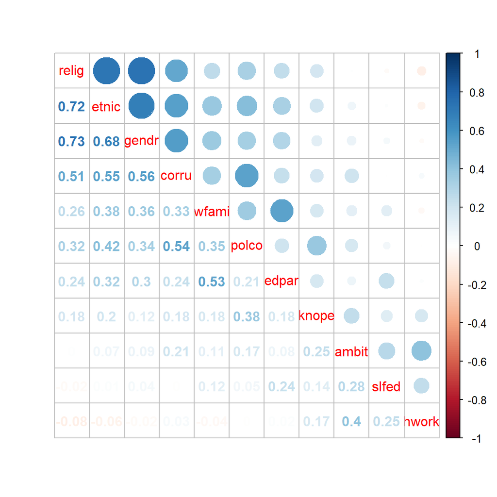

**Correlación Policórica para Batería de *Percepción* en Meritocracia para Chile ISSP 2009**

Analisis Factorial 2009 Percepcion

|  | Factor 1 | Factor 2 | Factor 3 | Factor 4 |
| --- | --- | --- | --- | --- |
| Q1a Getting ahead: How important is coming from a wealthy family? | -0.02 | 0.61 | 0.22 | -0.07 |
| Q1b Getting ahead: How important is having well-educated parents? | 0.05 | 0.78 | -0.07 | -0.02 |
| Q1c Getting ahead: How important is having a good education yourself? | -0.01 | 0.21 | -0.09 | 0.33 |
| Q1d Getting ahead: How Important is having ambition? | -0.03 | -0.06 | 0.18 | 0.62 |
| Q1e Getting ahead: How important is hard work? | 0.02 | -0.11 | -0.04 | 0.57 |
| Q1g Getting ahead: How important is having political connections? | -0.07 | 0.07 | 0.72 | -0.00 |
| Q1h Getting ahead: How important is giving bribes? | 0.31 | -0.04 | 0.45 | 0.08 |
| Q1i Getting ahead: How important is a person’s race? | 0.66 | 0.08 | 0.11 | -0.04 |
| Q1j Getting ahead: How important is a person’s religion? | 0.91 | -0.06 | -0.11 | -0.04 |
| Q1k Getting ahead: How important is being born a man or a woman? | 0.78 | 0.05 | -0.04 | 0.04 |
| Cronbach’s α | 0.82 | 0.67 | 0.60 | 0.49 |

### Preferencia

- V47:Importancia para pagar: el nivel de responsabilidad que tiene el trabajo (respo)
- V48:Importancia para pagar: el numero de años dedicados a la educación y capacitación (neduc)
- V49:Importancia para pagar: lo que se necesita para mantener una familia (mafam)
- V50:Importancia para pagar: El que la persona tenga hijos que mantener (hchil)
- V51:Importancia para pagar: lo bien que él o ella realiza su tabajo (gdwrk)
- V52:Importancia para pagar: Lo que él o ella se esfuerza al realizar su trabajo (effor)

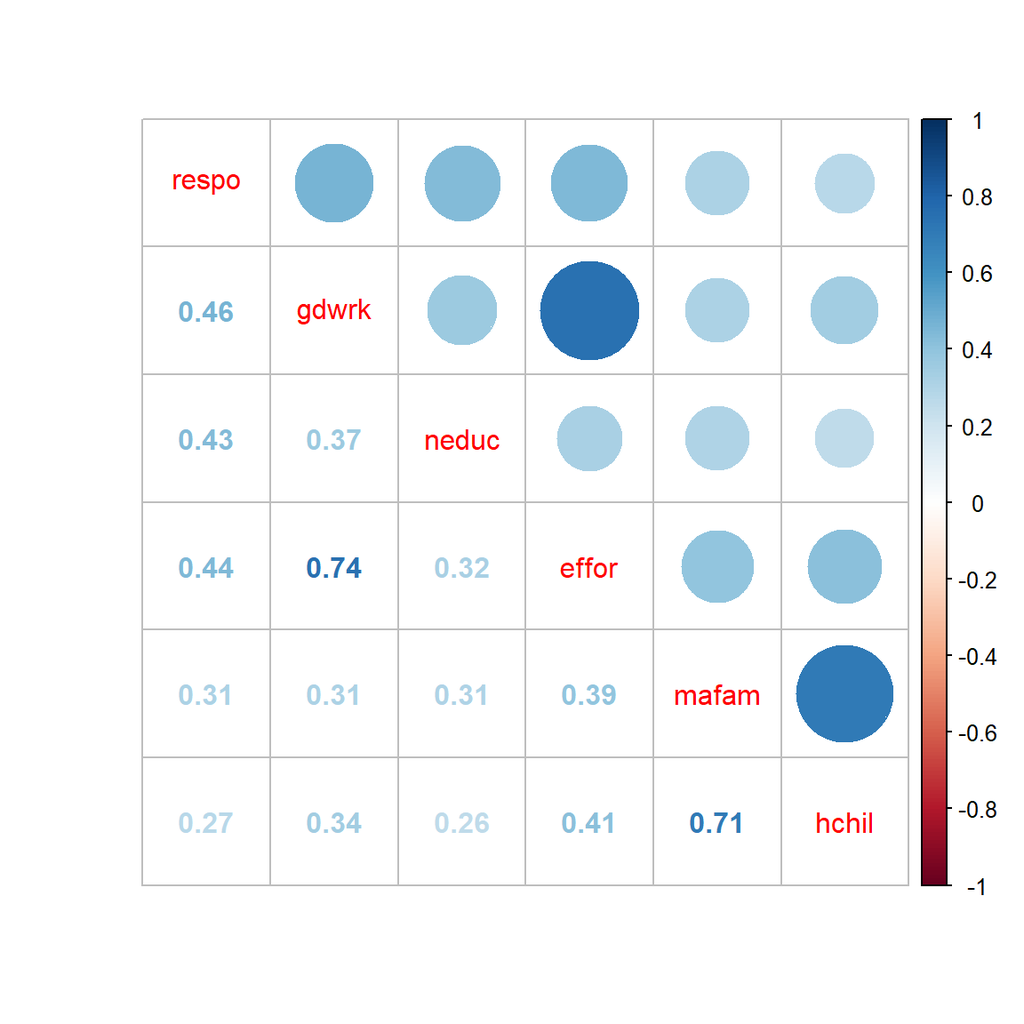

**Correlación Policórica para Batería de *Preferencias* en Meritocracia para Chile ISSP 2009**

Analisis Factorial 2009 Preferencia

|  | Factor 1 | Factor 2 |
| --- | --- | --- |
| Q12a Important for pay: How much responsibility goes with the job? | 0.48 | 0.04 |
| Q12b Important for pay: the number of years spent in education and training? | 0.35 | 0.10 |
| Q12c Important for pay: what is needed to support a family? | -0.09 | 0.99 |
| Q12d Important for pay: whether the person has children to support? | 0.06 | 0.66 |
| Q12e Important for pay: how well he or she does the job? | 0.93 | -0.17 |
| Q12f Important for pay: How hard he or she works at the job? | 0.76 | 0.00 |
| Cronbach’s α | 0.71 | 0.79 |

## 2019

### Percepción

**(1) Esencial - No tiene importancia (5)** (8 no sabe, 9 no responde)

- M2_P1_1 : Para surgir en la vida: Tener ambición
- M2_P1_2 : Para surgir en la vida: Provenir de una familia rica
- M2_P1_3 : Para surgir en la vida: Tener padres con buen nivel de educación
- M2_P1_4 : Para surgir en la vida: Que UD tenga un buen nivel de educación
- M2_P1_5 : Para surgir en la vida: El Trabajo Duro
- M2_P1_6 : Para surgir en la vida: Conocer a la personas adecuadas
- M2_P1_7 : Para surgir en la vida: Tener contactos políticos
- M2_P1_8 : Para surgir en la vida: Pagar coimas
- M2_P1_9 : Para surgir en la vida: La raza u origen étnico de la persona
- M2_P1_10: Para surgir en la vida: la religión de las personas
- M2_P1_11: Para surgir en la vida: el sexo de las personas

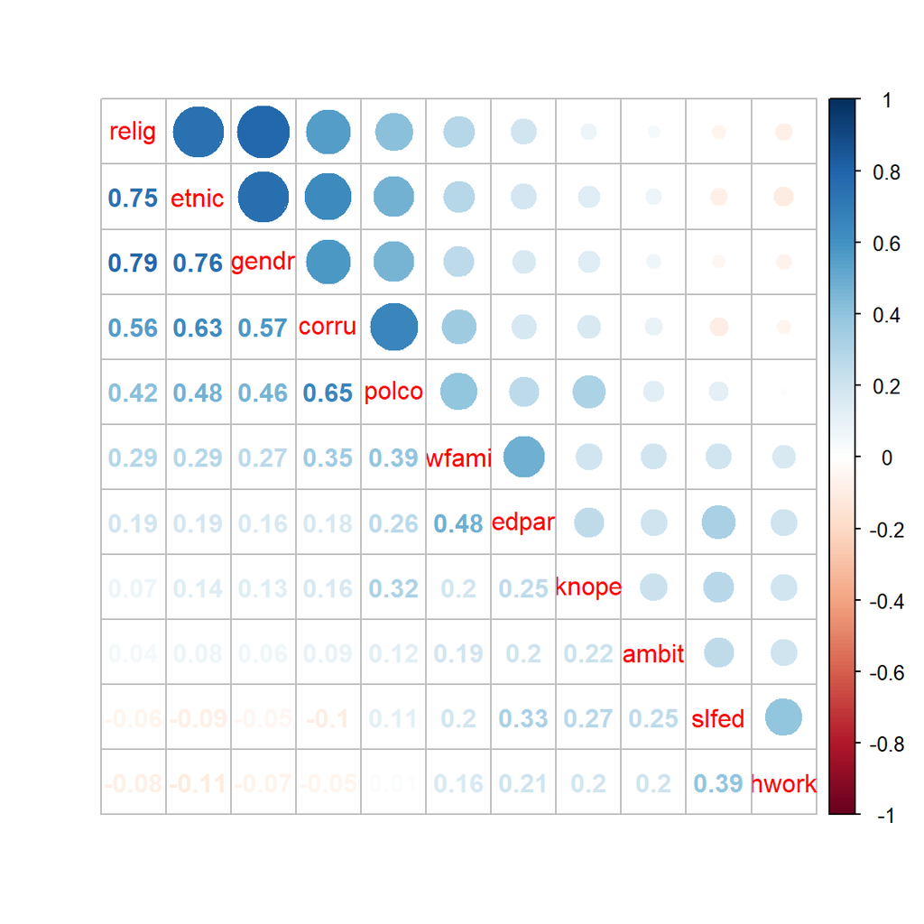

**Correlación Policórica para Batería de *Percepción* en Meritocracia para Chile ISSP 2019**

|  | Factor 1 | Factor 2 | Factor 3 | Factor 4 |
| --- | --- | --- | --- | --- |
| Para surgir en la vida, ¿cuán importante cree Ud. que es "Provenir de una famili | -0.01 | -0.09 | 0.13 | 0.67 |
| Para surgir en la vida, ¿cuán importante cree Ud. que es "Tener padres con altos | 0.06 | 0.03 | -0.07 | 0.67 |
| Para surgir en la vida, ¿cuán importante cree Ud. que es "Que Ud. tenga un buen | 0.09 | 1.10 | 0.08 | -0.20 |
| Para surgir en la vida, ¿cuán importante cree Ud. que es “El trabajo duro”? | -0.05 | 0.27 | -0.03 | 0.15 |
| Para surgir en la vida, ¿cuán importante cree Ud. que es "Tener contactos políti | 0.01 | 0.07 | 0.63 | 0.10 |
| Para surgir en la vida, ¿cuán importante cree Ud. que es “Pagar coimas”? | 0.04 | -0.03 | 0.84 | -0.06 |
| Para surgir en la vida, ¿cuán importante cree Ud. que es "La raza u origen étnic | 0.71 | -0.02 | 0.13 | 0.02 |
| Para surgir en la vida, ¿cuán importante cree Ud. que es "La religión de las per | 0.86 | 0.01 | -0.07 | 0.05 |
| Para surgir en la vida, ¿cuán importante cree Ud. que es "El sexo de las persona | 0.86 | 0.03 | -0.00 | -0.01 |
| Cronbach’s α | 0.86 | 0.50 | 0.71 | 0.62 |

### Preferencia

- M2_P14_1: Importancia para ganar: El nivel de responsabilidad que tiene su trabajo
- M2_P14_2: Importancia para ganar: El número de años dedicados a educación y capacitación
- M2_P14_3: Importancia para ganar: El que la persona tenga hijos que mantener
- M2_P14_4: Importancia para ganar: Lo bien que él o ella realiza su trabajo

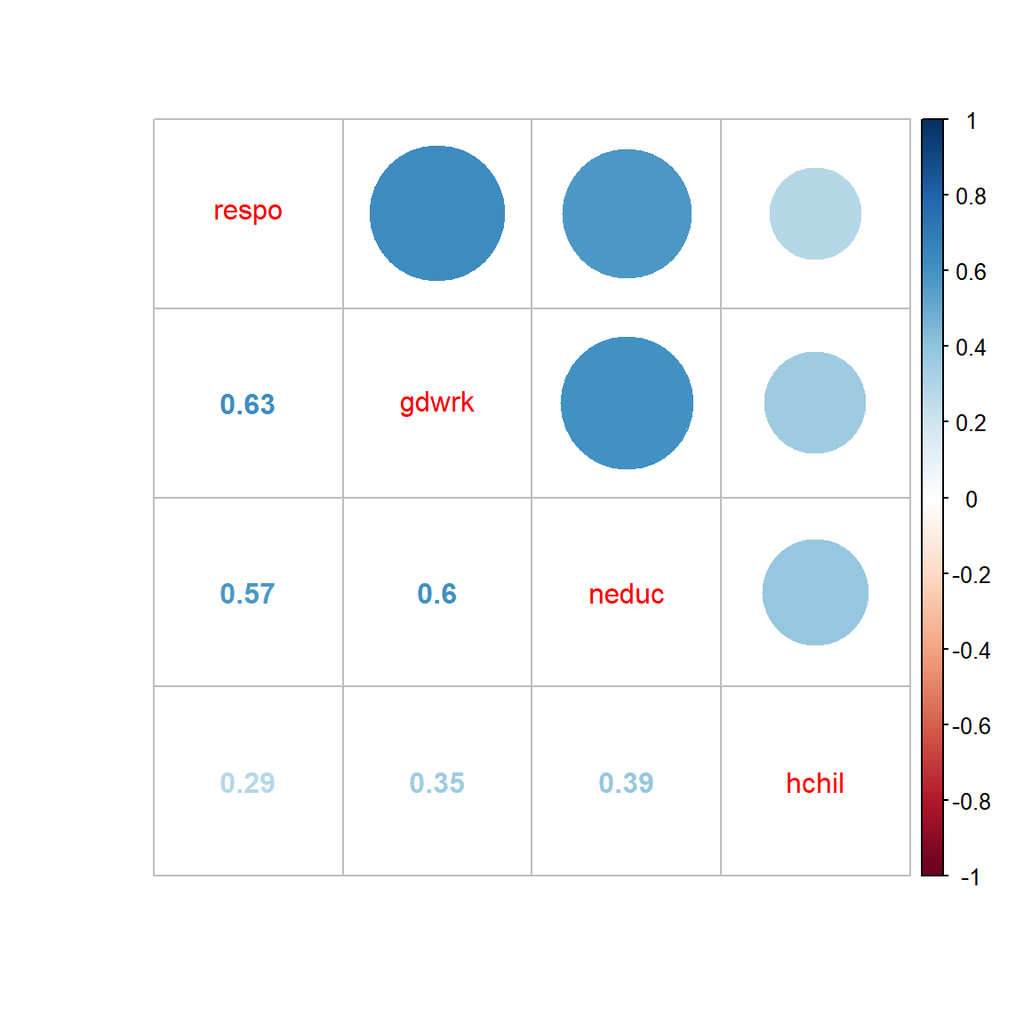

**Correlación Policórica para Batería de *Preferencias* en Meritocracia para Chile ISSP 2019**

# Meritocracia y Brecha Salarial Justa